# Hypothesis Testing II

Arash Hatamirad, ahatamirad@gmail.com

9/1/2021

The airquality data will be used for this Exercise. The information about variables in the dataset can be found in R.

## Exercise: Hypothesis Testing

Perform a hypothesis test -whether Wind in July has a different speed (mph) than Wind in August.

#### Question (a):

- Which test should we perform, and why? See QQ-plot and perform Shapiro-Wilk test for normality check.

#### Answer -:

- we must compare “Wind” variable in July with “Wind” variable in August
- Since we have “Two-Populations”, we have to check normality for both samples.

```r
# Filter the July & August data

wind.july=airquality %>%
  filter(airquality$Month==7)

wind.august=airquality %>%
  filter(airquality$Month==8)
```

##### Visual method (QQ Plot)

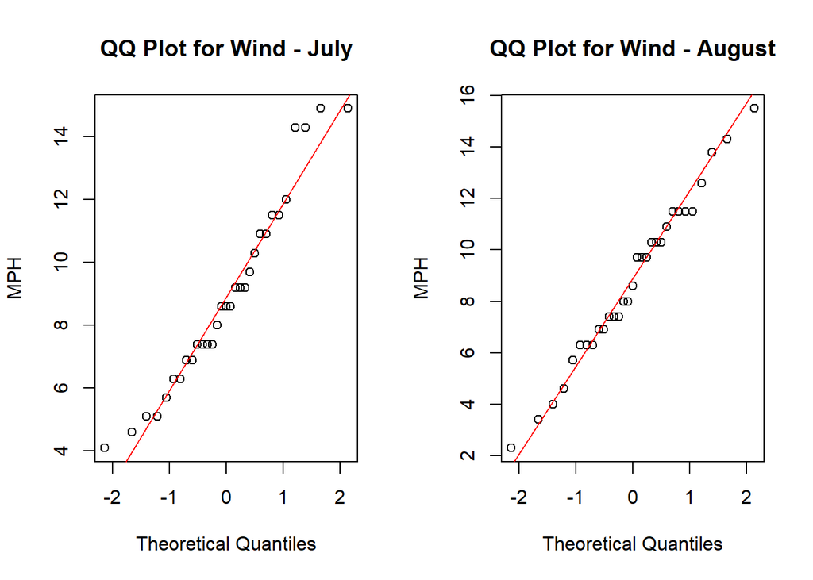

```r
# divide 1X2
par(mfrow=c(1,2))

# QQ Plot for wind, July
qqnorm(wind.july$Wind,main = "QQ Plot for Wind - July",ylab="MPH")
qqline(wind.july$Wind,col="red")


# QQ Plot for wind, August
qqnorm(wind.august$Wind,main = "QQ Plot for Wind - August",ylab = "MPH")
qqline(wind.august$Wind,col="red")
```

##### Shapiro-Wilk Test

- H0: Data follows normal distribution
- H1: Data doesn’t follow normal distribution

```r
# shapiro-Wilk Test

#Print P-Value for July
wind.july$Wind %>%
  shapiro.test() %>%
  print()
```

```
##
##  Shapiro-Wilk normality test
##
## data:  .
## W = 0.95003, p-value = 0.1564
```

```r
# Print P-Value for August
wind.august$Wind %>%
  shapiro.test() %>%
  print()
```

```
##
##  Shapiro-Wilk normality test
##
## data:  .
## W = 0.98533, p-value = 0.937
```

##### comments:

According to the QQ-Plot, there are a majority points near the red line and regarding to P-Values:  
P-Value > Significant Value  
therefore, we don’t have enough evidence to reject the “Null Hypothesis”, hence both data follow normal distribution.

##### Conclusion:

Both data follow normal distribution, therefore we should perform “T-Test”.

#### Question (b):

- Specify null and alternative hypotheses

#### Answer -:

- Null Hypothesis (H0):
- Mean of wind in July = Mean of wind in August, it means Wind in July has similar speed (mph) as Wind in August.
- Alternate Hypothesis (H1):
- Mean of wind in July != Mean of wind in August, it means Wind in July has different speed (mph) with Wind in August.

#### Question (c):

- State the conclusion based on the test result.

#### Answer -:

1- We must check the variances for both data is equal or not.

- H0 : Two groups have the same variances
- H1 : Two groups have different variances

```r
# Make a Union data frame, incluse July and August data
wind.july.august=union(wind.july,wind.august)

# Check the Variances
var.test(wind.july.august$Wind ~ wind.july.august$Month, alternative="two.sided")
```

```
##
##  F test to compare two variances
##
## data:  wind.july.august$Wind by wind.july.august$Month
## F = 0.8857, num df = 30, denom df = 30, p-value = 0.7418
## alternative hypothesis: true ratio of variances is not equal to 1
## 95 percent confidence interval:
##  0.4270624 1.8368992
## sample estimates:
## ratio of variances
##          0.8857035
```

##### comments:

According to the P-Value, because it’s very bigger than significant value, thus we don’t have enough evidence to reject H0

- Two groups have the same variances, hence we will run Pooled T-Test

```r
# Run pooled T-Test

t.test(wind.july.august$Wind ~ wind.july.august$Month,alternative="two.sided",var.equal=TRUE)
```

```
##
##  Two Sample t-test
##
## data:  wind.july.august$Wind by wind.july.august$Month
## t = 0.1865, df = 60, p-value = 0.8527
## alternative hypothesis: true difference in means between group 7 and group 8 is not equal to 0
## 95 percent confidence interval:
##  -1.443108  1.739883
## sample estimates:
## mean in group 7 mean in group 8
##        8.941935        8.793548
```

#### Conclusion:

- P-Value >> significant value  
  P-Value is very bigger then significant value,therefor we don’t have enough evidence to reject H0
- result: Mean of wind in July = Mean of wind in August, it means Wind in July has similar speed (mph) as Wind in August.